# Within analysis and Between Model Comparison

31/03/2022

## Bicchieri Analysis

This analysis is performed on “Evidence from a long-term experiment that collective risks change social norms and promote cooperation”. All rounds are included and we performed a “Fit Linear Mixed-Effects Model”. The effects are “treatment_id” and “round number”.

The following results show the coefficients for the experiment’s first and replicated version. The independent variables of the model are “normative expectations”, “empirical expectations” and “personal normative beliefs”.

I also tried to include the risk change during the experiment in this analysis. Still, the model fails to estimate variables correctly due to too many effects (treatment, round and risk). For this reason, I choose to show the model without the risk effect.

First and Replicated verison - all round, effects: treatment and round

|  | First |  |  | Replicated |  |  |
| --- | --- | --- | --- | --- | --- | --- |
| Predictors | Estimates | std. Error | p | Estimates | std. Error | p |
| ne avg | 0.22 | 0.06 | **<0.001** | 0.12 | 0.05 | **0.022** |
| ee avg | 0.47 | 0.04 | **<0.001** | 0.58 | 0.08 | **<0.001** |
| pnb | 0.56 | 0.03 | **<0.001** | 0.52 | 0.04 | **<0.001** |
| Random Effects |  |  |  |  |  |  |
| σ<sup>2</sup> | 127.49 |  |  | 113.15 |  |  |
| τ<sub>00</sub> | 115.68 <sub>round</sub> |  |  | 385.92 <sub>round</sub> |  |  |
|  | 281.06 <sub>treatment</sub> |  |  | 699.90 <sub>treatment</sub> |  |  |
| τ<sub>11</sub> | 0.08 <sub>round.ne_avg</sub> |  |  | 0.05 <sub>round.ne_avg</sub> |  |  |
|  | 0.03 <sub>round.ee_avg</sub> |  |  | 0.14 <sub>round.ee_avg</sub> |  |  |
|  | 0.02 <sub>round.pnb</sub> |  |  | 0.04 <sub>round.pnb</sub> |  |  |
| ρ<sub>01</sub> | -1.00 <sub>round.ne_avg</sub> |  |  | -0.21 <sub>round.ne_avg</sub> |  |  |
|  | 0.61 <sub>round.ee_avg</sub> |  |  | -0.79 <sub>round.ee_avg</sub> |  |  |
|  | -0.23 <sub>round.pnb</sub> |  |  | -0.19 <sub>round.pnb</sub> |  |  |
| ICC |  |  |  | 0.86 |  |  |
| N | 2 <sub>treatment</sub> |  |  | 2 <sub>treatment</sub> |  |  |
|  | 28 <sub>round</sub> |  |  | 28 <sub>round</sub> |  |  |
| Observations | 7433 |  |  | 7748 |  |  |
| Marginal R<sup>2</sup> / Conditional R<sup>2</sup> | 0.312 / NA |  |  | 0.064 / 0.871 |  |  |
| AIC | 57273.773 |  |  | 58845.212 |  |  |
| log-Likelihood | -28621.887 |  |  | -29407.606 |  |  |

## Model Comparison (between studies)

This section shows the results of the model comparison for between studies.

For each game type, we have:

- plot of coefficients of Social Expectation model (Krupka & Weber 2013) $U_{ik} = \delta \pi_k + \gamma N_k + \epsilon_{ik}$
  - $\pi_k$ : payoff
  - $N_k$ : norm appropriateness
- plot of coefficients of Social Preferencesn model (Charness & Rabin 2002) $U_{ik} = (\rho * r + \sigma * s)(W-k_i) + (1 - \rho * r - \sigma * s)k_i$
  - $k_i$ : dictator’s payoff
  - $W$ : initial endowment
  - $r=1$ if $k_i>5$, in this case, $\rho$ indicates the concern for the others only when dictator has more than the others
  - $s=1$ if $k_i<5$, in this case, **$\sigma$** indicates the concern for the others only when dictator has less than the others
- plot of AIC comparison

### Dictator Game

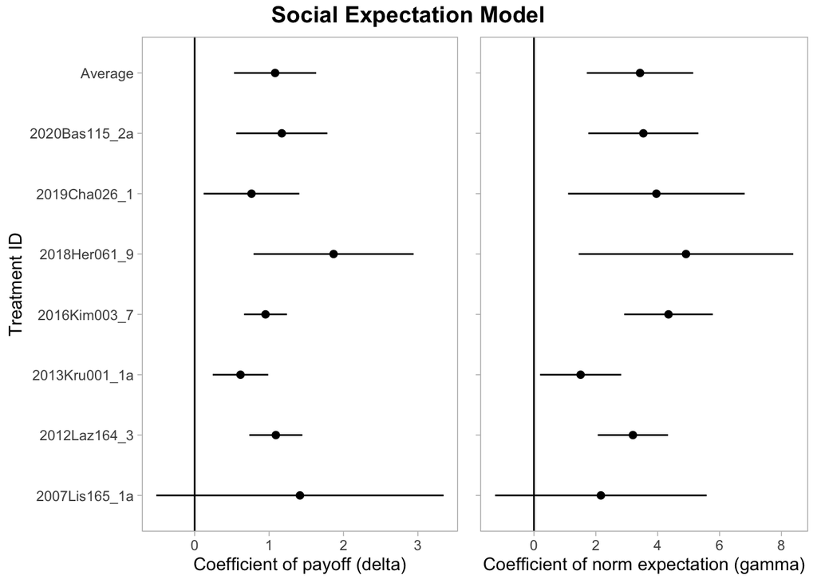

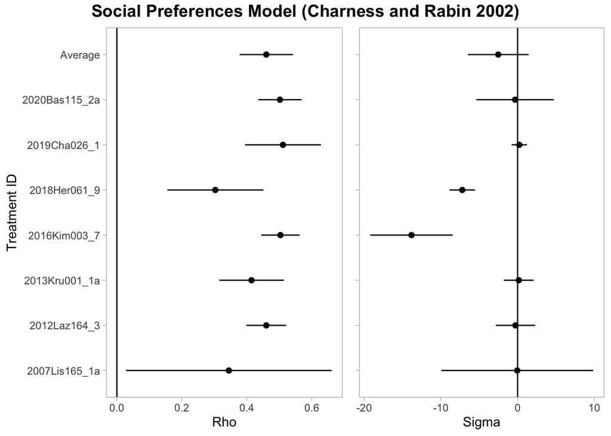

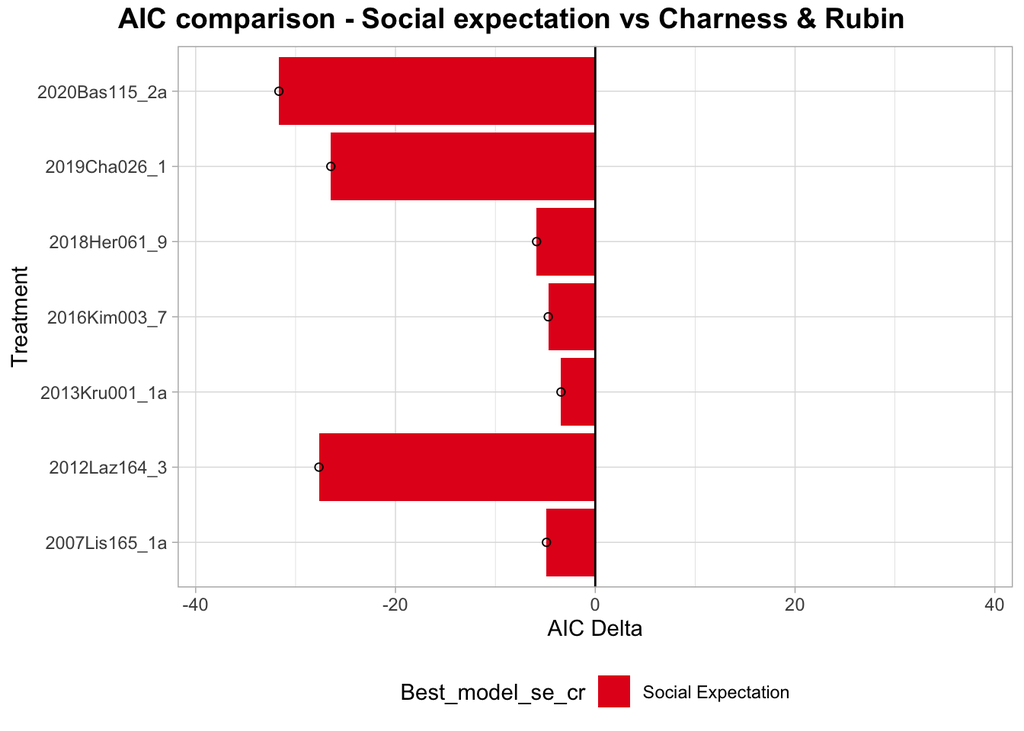

### Take or Give

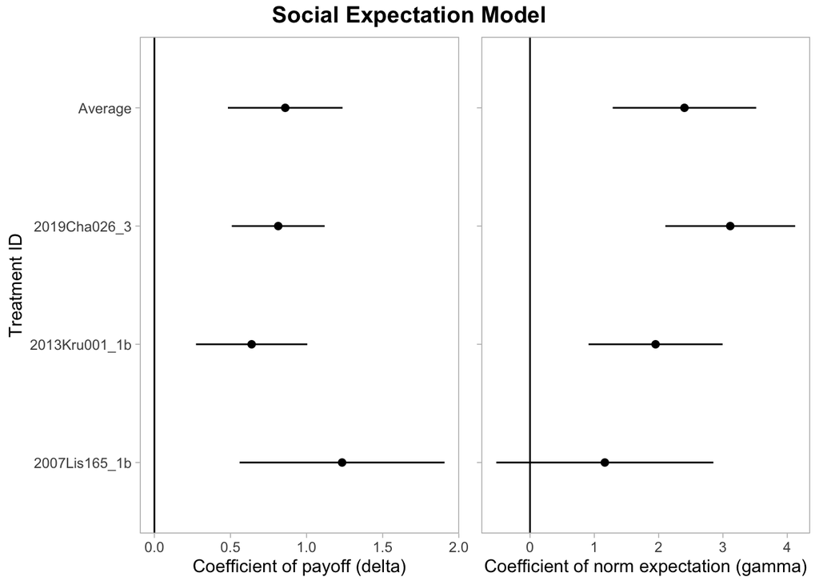

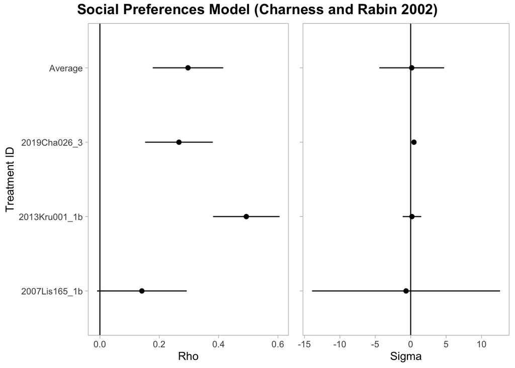

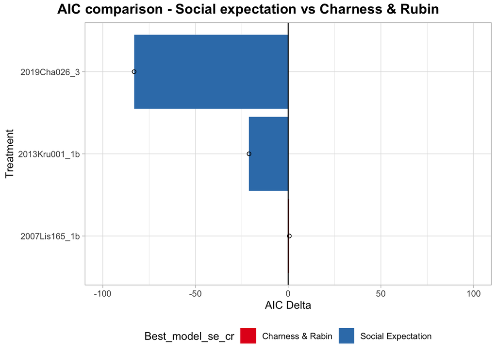

### Donation Game

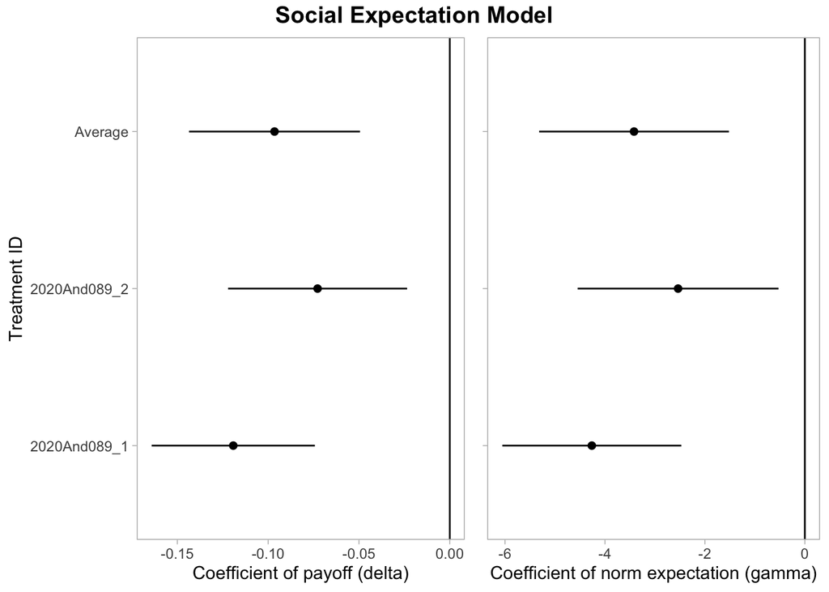

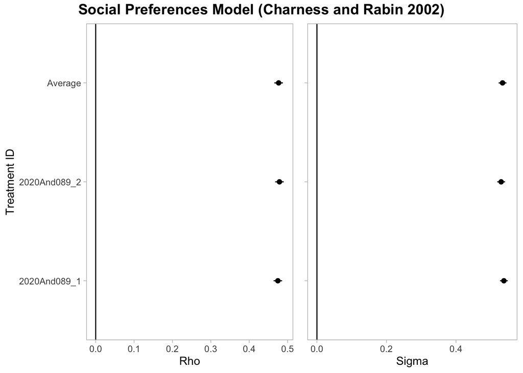

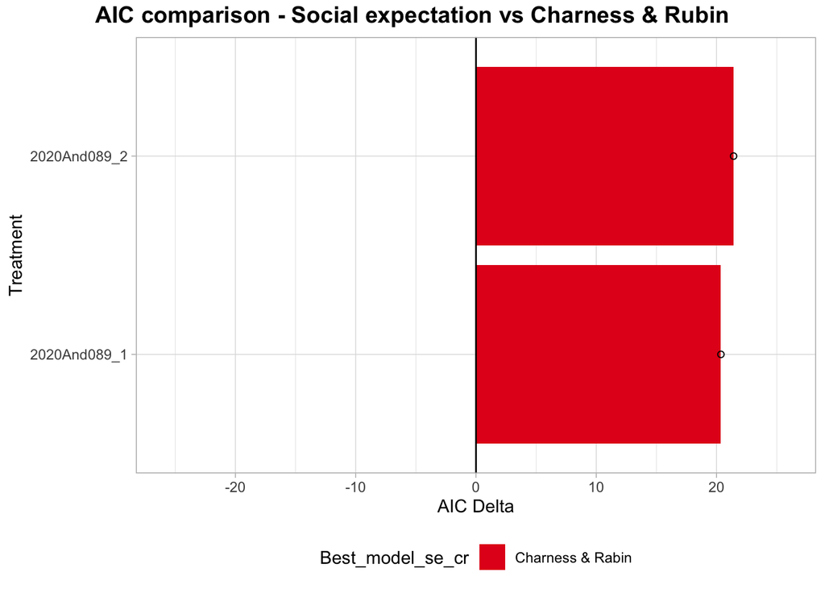